# Principal Component Analysis

Dataset water.zostera.all.scaled.noout

This dataset contains 28 individuals and 9 variables, 1 qualitative variable is considered as illustrative.

### 1. Inertia distribution

The inertia of the first dimensions shows if there are strong relationships between variables and suggests the number of dimensions that should be studied.

The first two dimensions of PCA express **63.93%** of the total dataset inertia ; that means that 63.93% of the individuals (or variables) cloud total variability is explained by the plane. This percentage is relatively high and thus the first plane well represents the data variability. This value is greater than the reference value that equals **49.58%**, the variability explained by this plane is thus significant (the reference value is the 0.95-quantile of the inertia percentages distribution obtained by simulating 850 data tables of equivalent size on the basis of a normal distribution).

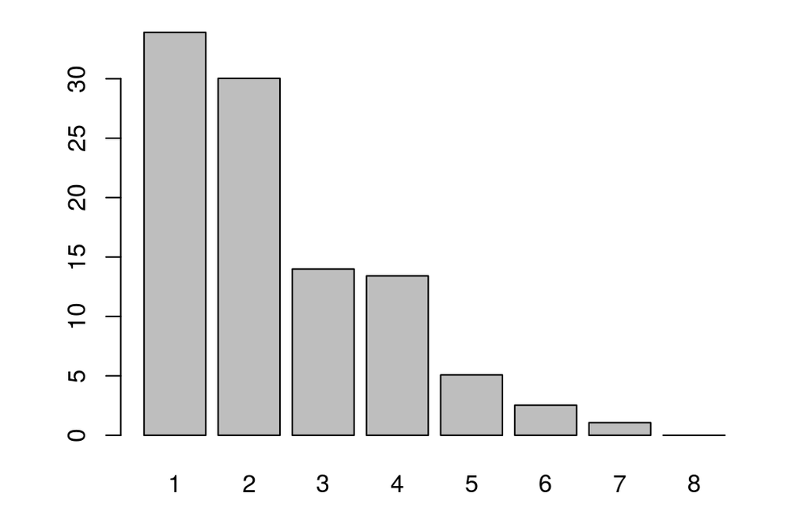

**Figure 1 - Decomposition of the total inertia on the components of the PCA**

An estimation of the right number of axis to interpret suggests to restrict the analysis to the description of the first 2 axis. These axis present an amount of inertia greater than those obtained by the 0.95-quantile of random distributions (63.93% against 49.58%). This observation suggests that only these axis are carrying a real information. As a consequence, the description will stand to these axis.

### 2. Description of the plane 1:2

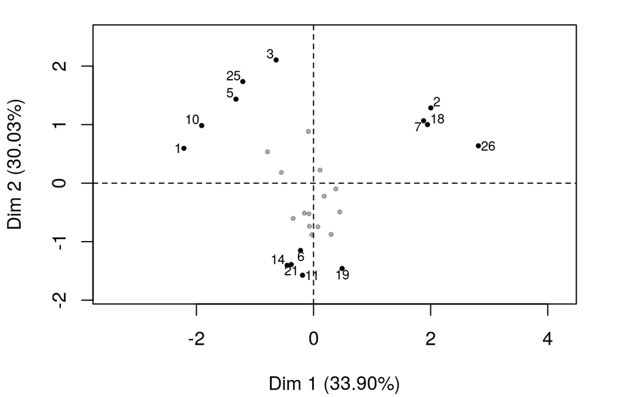

**Figure 2.1 - Individuals factor map (PCA)** *The labeled individuals are those with the higher contribution to the plane construction.*

The Wilks test p-value indicates which variable factors are the best separated on the plane (i.e. which one explain the best the distance between individuals).

```
##   station
## 0.1831431
```

There only is one possible qualitative variable to illustrate the distance between individuals : *station*.

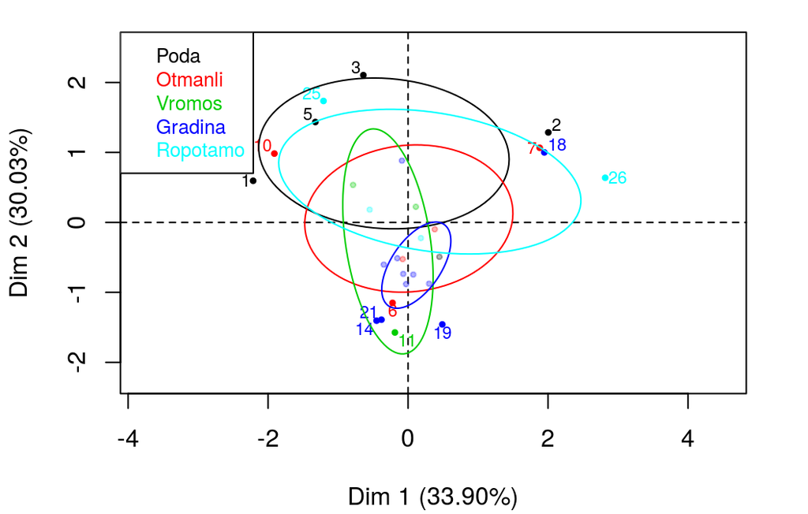

**Figure 2.2 - Individuals factor map (PCA)** *The labeled individuals are those with the higher contribution to the plane construction.* *The individuals are coloured after their category for the variable* station.

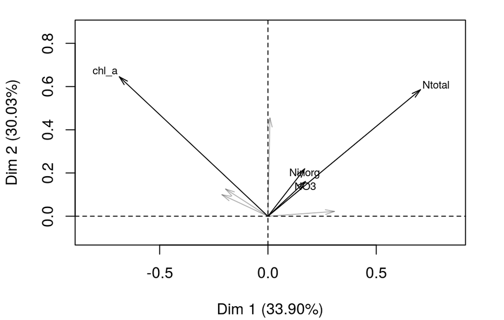

**Figure 2.3 - Variables factor map (PCA)** *The labeled variables are those the best shown on the plane.*

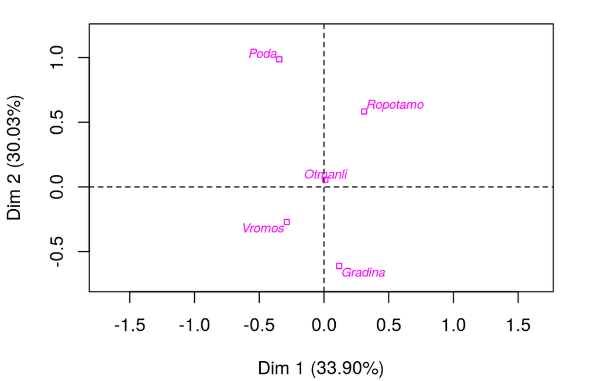

**Figure 2.4 - Qualitative factor map (PCA)** *The labeled factors are those the best shown on the plane.*

The **dimension 1** opposes individuals such as *7*, *2* and *26* (to the right of the graph, characterized by a strongly positive coordinate on the axis) to individuals such as *1*, *10*, *5*, *25* and *3* (to the left of the graph, characterized by a strongly negative coordinate on the axis).

The group in which the individuals *1*, *10*, *5*, *25* and *3* stand (characterized by a negative coordinate on the axis) is sharing :

The **dimension 2** opposes individuals such as *1*, *10*, *5*, *25* and *3* (to the top of the graph, characterized by a strongly positive coordinate on the axis) to individuals such as *19*, *21*, *6*, *11* and *14* (to the bottom of the graph, characterized by a strongly negative coordinate on the axis).

### 3. Classification

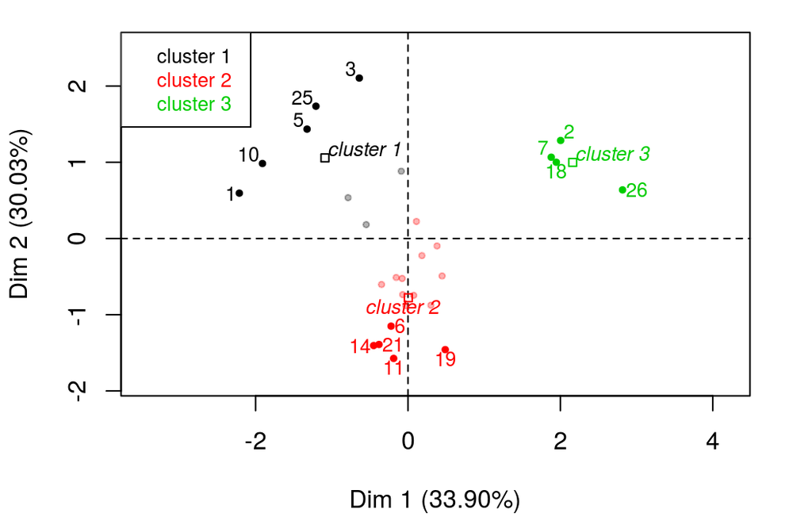

**Figure 3 - Ascending Hierarchical Classification of the individuals.** *The classification made on individuals reveals 3 clusters.*

The **cluster 1** is made of individuals such as *1*, *3*, *5*, *10* and *25*. This group is characterized by :

- high values for the variables *chl_a*, *PO4* and *NH4* (variables are sorted from the strongest).

The **cluster 2** is made of individuals such as *6*, *11*, *14*, *19* and *21*. This group is characterized by :

- low values for the variables *chl_a*, *Ninorg*, *NH4*, *Ntotal* and *NO3* (variables are sorted from the weakest).

The **cluster 3** is made of individuals such as *2*, *7*, *18* and *26*. This group is characterized by :

- high values for the variables *Ntotal*, *Ninorg*, *NO3* and *secchi* (variables are sorted from the strongest).
- low values for the variable *PO4*.

## Annexes

```r
dimdesc(res, axes = 1:2)
```

```
$Dim.1
$Dim.1$quanti
       correlation      p.value
Ntotal   0.7331234 9.107773e-06
NO3      0.5512732 2.361413e-03
Ninorg   0.4921647 7.805791e-03
secchi   0.4476932 1.689718e-02
PO4     -0.6224777 4.044031e-04
chl_a   -0.6949508 4.062880e-05


$Dim.2
$Dim.2$quanti
       correlation      p.value
chl_a    0.6534747 0.0001628867
Ninorg   0.6366456 0.0002701456
NH4      0.6095853 0.0005742181
Ntotal   0.6094530 0.0005762427
NO3      0.5127845 0.0052672129

$Dim.2$quali
              R2    p.value
station 0.353961 0.03334501

$Dim.2$category
          Estimate    p.value
Poda     0.8374476 0.01759672
Gradina -0.7595187 0.01040919
```

**Figure 4 - List of variables characterizing the dimensions of the analysis.**

```r
res.hcpc$desc.var
```

```
Link between the cluster variable and the quantitative variables
================================================================
            Eta2      P-value
chl_a  0.7836277 4.898020e-09
Ntotal 0.6813993 6.174239e-07
Ninorg 0.5504920 4.562655e-05
NO3    0.4888117 2.276468e-04
PO4    0.3904075 2.055867e-03
NH4    0.3147313 8.876905e-03

Description of each cluster by quantitative variables
=====================================================
$`1`
        v.test Mean in category Overall mean sd in category Overall sd
chl_a 4.587786        1.3605661   -0.0177671      0.6462303  0.9873313
PO4   2.901954        0.1081105   -0.1931391      0.3465209  0.3411519
NH4   2.161697        0.3064516   -0.1838363      0.7047694  0.7453637
           p.value
chl_a 4.479705e-06
PO4   3.708431e-03
NH4   3.064154e-02

$`2`
          v.test Mean in category Overall mean sd in category Overall sd
NO3    -2.444441       -0.3024983   -0.1746875     0.08100675  0.3137177
Ntotal -2.534650       -0.5254172   -0.1195373     0.60424581  0.9607953
NH4    -2.914686       -0.5459199   -0.1838363     0.41062982  0.7453637
Ninorg -3.037014       -0.3593869   -0.1850314     0.10293586  0.3444610
chl_a  -3.123709       -0.5317897   -0.0177671     0.38825783  0.9873313
           p.value
NO3    0.014507684
Ntotal 0.011255984
NH4    0.003560466
Ninorg 0.002389346
chl_a  0.001785872

$`3`
          v.test Mean in category Overall mean sd in category Overall sd
Ntotal  4.246499        1.8038011  -0.11953726      0.2051836  0.9607953
Ninorg  3.526068        0.3875333  -0.18503137      0.3753891  0.3444610
NO3     3.522467        0.3462430  -0.17468754      0.4328235  0.3137177
secchi  2.009447        0.5602348  -0.08845813      1.3463061  0.6848082
PO4    -2.155822       -0.5398395  -0.19313908      0.1180940  0.3411519
            p.value
Ntotal 2.171364e-05
Ninorg 4.217788e-04
NO3    4.275496e-04
secchi 4.448980e-02
PO4    3.109760e-02
```

**Figure 5 - List of variables characterizing the clusters of the classification.**